# R Notebook

On récupére l’ensemble des donnés

```r
library(devtools)
library(flexdashboard)
library(lubridate)
library(dplyr)
library(ggplot2)
library(ggstance)
library(ggalt)
library(readxl)

fatalEncounters <- read.csv("FatalEncounters.csv", header=TRUE, sep=",")
WahsingtonPost <- read.csv("WahsingtonPostDatabase.csv", header=TRUE, sep=",")
WahsingtonPost$date <- ymd(WahsingtonPost$date)
policeDeaths <- read.csv("PoliceDeaths.csv", header=TRUE, sep=",")

TaxPolicyCenter <- read_excel("TaxPolicyCenter.xls" )
```

```
* `` -> ...1
* `` -> ...2
* `` -> ...3
* `` -> ...4
* `` -> ...6
* ...
```

```r
TaxPolicyCenter <- na.omit(TaxPolicyCenter)
names(TaxPolicyCenter) <- c('regionsandstates', 'total','intergovernmental','total2', 'Elementaryandsecondaryeducation', 'Highereducation', 'Publicwelfare',
                       'healthandhospital', 'highways', 'police', 'all other', 'ExhibitpersonalIncome[1](millions)')
TaxPolicyCenter$police <- as.numeric(as.character(TaxPolicyCenter$police))
```

Le nombre de civils tués durant un intervention présentant des troubles menteaux

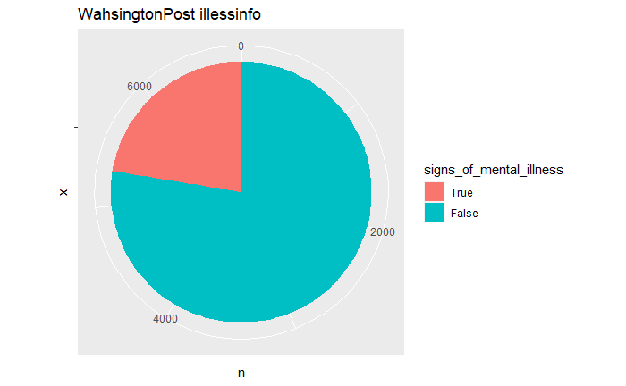

```r
illessinfo <- WahsingtonPost %>% group_by(signs_of_mental_illness) %>% summarise(n = n()) %>%
  arrange(signs_of_mental_illness) %>%
  mutate(signs_of_mental_illness = factor(signs_of_mental_illness, levels = rev(unique(signs_of_mental_illness))))

ggplot(illessinfo, aes(x="", y=n, fill=signs_of_mental_illness))+
  geom_bar(width = 1, stat = "identity")+
  ggtitle("WahsingtonPost illessinfo")+
  coord_polar("y", start=0)
```

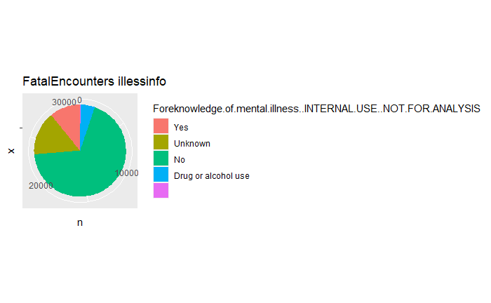

```r
illessinfo <- fatalEncounters %>% group_by(Foreknowledge.of.mental.illness..INTERNAL.USE..NOT.FOR.ANALYSIS) %>% summarise(n = n()) %>%
  arrange(Foreknowledge.of.mental.illness..INTERNAL.USE..NOT.FOR.ANALYSIS) %>%
  mutate(Foreknowledge.of.mental.illness..INTERNAL.USE..NOT.FOR.ANALYSIS = factor(Foreknowledge.of.mental.illness..INTERNAL.USE..NOT.FOR.ANALYSIS, levels = rev(unique(Foreknowledge.of.mental.illness..INTERNAL.USE..NOT.FOR.ANALYSIS))))

ggplot(illessinfo, aes(x="", y=n, fill=Foreknowledge.of.mental.illness..INTERNAL.USE..NOT.FOR.ANALYSIS))+
  geom_bar(width = 1, stat = "identity")+
  ggtitle("FatalEncounters illessinfo")+
  coord_polar("y", start=0)
```

comparont maintenant les deux bases concernant les civils a savoir fatalencouter et wahsingtonPost sur les niveaux de danger, les armes et les delits de fuites

Commençont par le niveau d’armes:

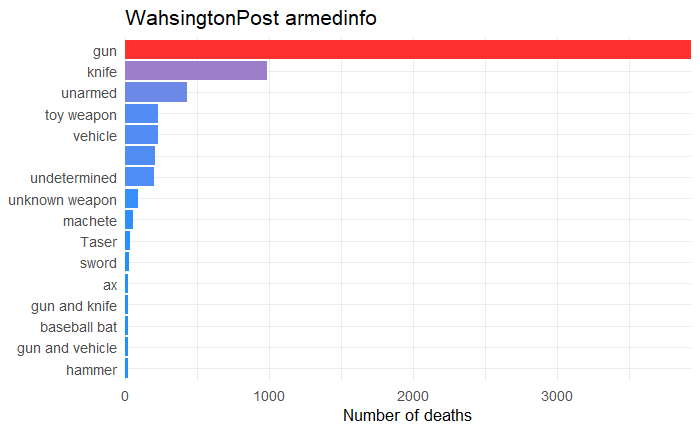

```r
armedinfo <- WahsingtonPost %>% group_by(armed) %>% summarise(n = n()) %>%
  arrange(desc(n)) %>% top_n(15) %>%
  mutate(armed = factor(armed, levels = rev(unique(armed))))
ggplot(data = armedinfo, aes(x = n, y = armed)) +
  geom_barh(stat="identity", aes(fill = n)) +
  ggtitle("WahsingtonPost armedinfo")+
  theme_minimal(base_size = 13) +
  theme(legend.position = "none") +
  scale_x_continuous(expand=c(0,0)) +
  scale_fill_gradient(low = "dodgerblue", high = "firebrick1") +
  labs(y = NULL, x = "Number of deaths")
```

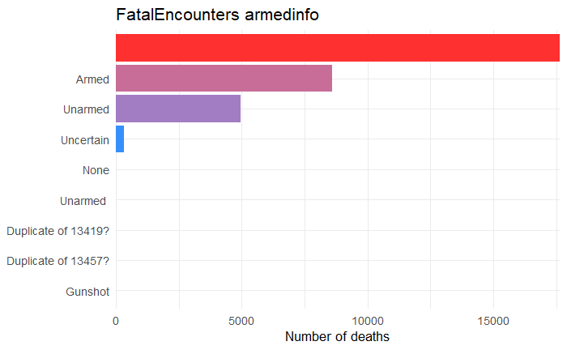

```r
armedinfo <- fatalEncounters %>% group_by(Armed.Unarmed) %>% summarise(n = n()) %>%
  arrange(desc(n))  %>%
  mutate(Armed.Unarmed = factor(Armed.Unarmed, levels = rev(unique(Armed.Unarmed))))

ggplot(data = armedinfo, aes(x = n, y = Armed.Unarmed)) +
  geom_barh(stat="identity", aes(fill = n)) +
  ggtitle("FatalEncounters armedinfo")+
  theme_minimal(base_size = 13) +
  theme(legend.position = "none") +
  scale_x_continuous(expand=c(0,0)) +
  scale_fill_gradient(low = "dodgerblue", high = "firebrick1") +
  labs(y = NULL, x = "Number of deaths")
```

Continuont sur le comportement et niveau de menace:

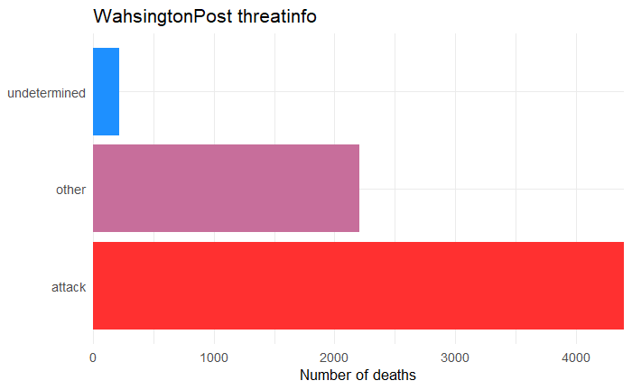

```r
threatinfo <- WahsingtonPost %>% group_by(threat_level) %>% summarise(n = n()) %>%
  arrange(desc(n))  %>%
  mutate(armed = factor(threat_level, levels = rev(unique(threat_level))))

ggplot(data = threatinfo, aes(x = n, y = threat_level)) +
  geom_barh(stat="identity", aes(fill = n)) +
  ggtitle("WahsingtonPost threatinfo")+
  theme_minimal(base_size = 13) +
  theme(legend.position = "none") +
  scale_x_continuous(expand=c(0,0)) +
  scale_fill_gradient(low = "dodgerblue", high = "firebrick1") +
  labs(y = NULL, x = "Number of deaths")
```

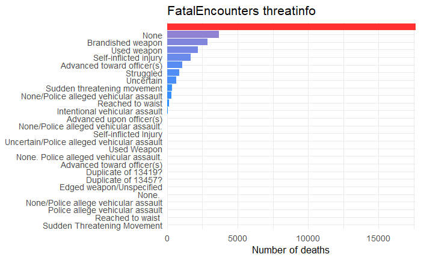

```r
threatinfo <- fatalEncounters %>% group_by(Aggressive.physical.movement) %>% summarise(n = n()) %>%
  arrange(desc(n))  %>%
  mutate(Aggressive.physical.movement = factor(Aggressive.physical.movement, levels = rev(unique(Aggressive.physical.movement))))

ggplot(data = threatinfo, aes(x = n, y = Aggressive.physical.movement)) +
  geom_barh(stat="identity", aes(fill = n)) +
  ggtitle("FatalEncounters threatinfo")+
  theme_minimal(base_size = 13) +
  theme(legend.position = "none") +
  scale_x_continuous(expand=c(0,0)) +
  scale_fill_gradient(low = "dodgerblue", high = "firebrick1") +
  labs(y = NULL, x = "Number of deaths")
```

On peut constater que donné de washingtonpost sont remplis beaucoup plus assidûment, de nombreuses colones de fatalEncouter sont réguliérement pas remplis ou non référencié. Peut-être que ces variations ne sont pas présentent sur tout les données on va donc étudié des donnés qui sont plus plus basée sur les personne et moins sur la confrontation.

Comparont déja l’origine ethnique de chacune des personnes décédés

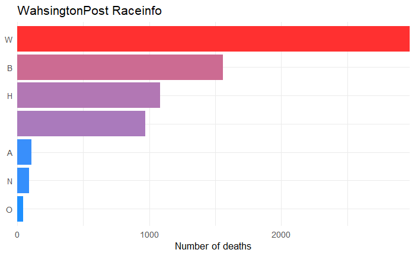

```r
raceinfo <- WahsingtonPost %>% group_by(race) %>% summarise(n = n()) %>%
  arrange(desc(n)) %>% mutate(race = factor(race, levels = rev(unique(race))))

ggplot(data = raceinfo, aes(x = n,y = race)) +
  geom_barh(stat="identity", aes(fill = n)) +
  ggtitle("WahsingtonPost Raceinfo")+
  theme_minimal(base_size = 13) +
  theme(legend.position = "none") +
  scale_x_continuous(expand=c(0,0)) +
  scale_fill_gradient(low = "dodgerblue", high = "firebrick1") +
  labs(y = NULL, x = "Number of deaths")
```

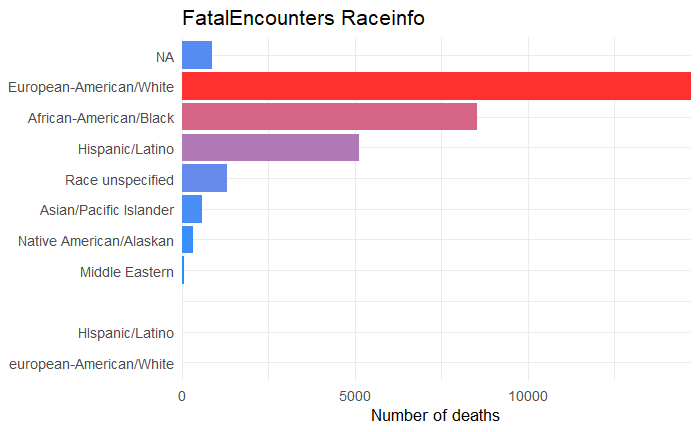

```r
raceinfo <- fatalEncounters %>% group_by(Race.with.imputations) %>% summarise(n = n()) %>%
  arrange(desc(n)) %>%
  mutate(Race.with.imputations = factor(Race.with.imputations, levels = rev(unique(Race.with.imputations))))

ggplot(data = raceinfo, aes(x = n,y = Race.with.imputations)) +
  geom_barh(stat="identity", aes(fill = n)) +
  ggtitle("FatalEncounters Raceinfo")+
  theme_minimal(base_size = 13) +
  theme(legend.position = "none") +
  scale_x_continuous(expand=c(0,0)) +
  scale_fill_gradient(low = "dodgerblue", high = "firebrick1") +
  labs(y = NULL, x = "Number of deaths")
```

```r
ggboxplot(WahsingtonPost, x = "race", y = "age") +
  ggtitle("WahsingtonPost Raceinfo and age comparaison")
```

```
Error in ggboxplot(WahsingtonPost, x = "race", y = "age") :
  could not find function "ggboxplot"
```

On serait vite tenter de déterminé une forme de descrimination ici cependant, il faut préciser que nous ne connaisons pas la répartitition des popultations sur le teritoire americain. Il est probable que les European-Americain/white represente une population majeur sur le téritoire americain toutefois, sans information suplementaire nous ne pouvons pas en déterminé plus.

comparont les age de chacun des database et essayon de trouver un tranche “cible”

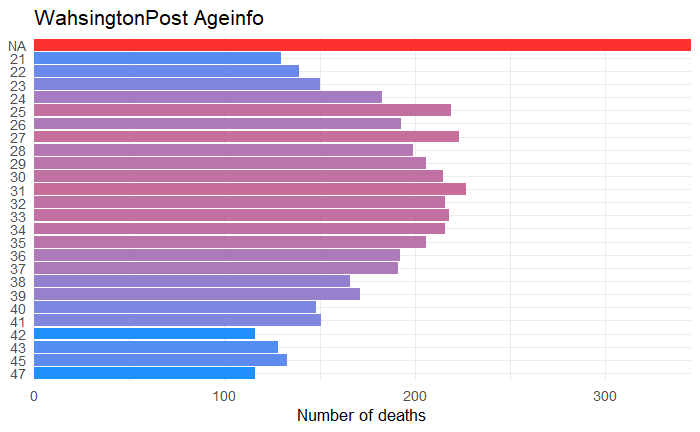

```r
ageinfo <- WahsingtonPost %>% group_by(age) %>% summarise(n = n()) %>%
  arrange(age) %>% top_n(25) %>%
  mutate(age = factor(age, levels = rev(unique(age))))
ggplot(data = ageinfo, aes(x = n,y = age)) +
  geom_barh(stat="identity", aes(fill = n)) +
  ggtitle("WahsingtonPost Ageinfo")+
  theme_minimal(base_size = 13) +
  theme(legend.position = "none") +
  scale_x_continuous(expand=c(0,0)) +
  scale_fill_gradient(low = "dodgerblue", high = "firebrick1") +
  labs(y = NULL, x = "Number of deaths")
```

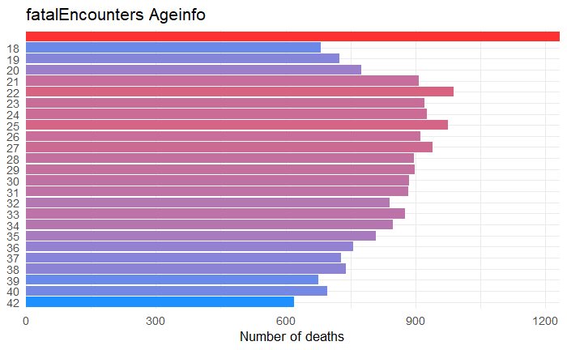

```r
ageinfo <- fatalEncounters %>% group_by(Age) %>% summarise(n = n()) %>%
  arrange(Age) %>% top_n(25) %>%
  mutate(Age = factor(Age, levels = rev(unique(Age))))
ggplot(data = ageinfo, aes(x = n,y = Age)) +
  geom_barh(stat="identity", aes(fill = n)) +
  ggtitle("fatalEncounters Ageinfo")+
  theme_minimal(base_size = 13) +
  theme(legend.position = "none") +
  scale_x_continuous(expand=c(0,0)) +
  scale_fill_gradient(low = "dodgerblue", high = "firebrick1") +
  labs(y = NULL, x = "Number of deaths")
```

```r
print("WahsingtonPost mean")
```

```
[1] "WahsingtonPost mean"
```

```r
result.mean <-  mean(WahsingtonPost$age,na.rm = TRUE)
print(result.mean)
```

```
[1] 37.1429
```

```r
print("fatalEncounters mean")
```

```
[1] "fatalEncounters mean"
```

```r
fatalEncounters$Age <- as.numeric(as.character(fatalEncounters$Age))
result.mean <-  mean(fatalEncounters$Age,na.rm = TRUE)
print(result.mean)
```

```
[1] 35.27834
```

```r
print("WahsingtonPost median")
```

```
[1] "WahsingtonPost median"
```

```r
result.median <-  median(WahsingtonPost$age,na.rm = TRUE)
print(result.median)
```

```
[1] 35
```

```r
print("fatalEncounters median")
```

```
[1] "fatalEncounters median"
```

```r
result.median <-  median(fatalEncounters$Age,na.rm = TRUE)
print(result.median)
```

```
[1] 33
```

```r
estimate_mode <- function(x) {
  d <- density(x,na.rm = TRUE)
  d$x[which.max(d$y)]
}

print("WahsingtonPost Mode")
```

```
[1] "WahsingtonPost Mode"
```

```r
result.mode <-  estimate_mode(WahsingtonPost$age)
print(result.mode)
```

```
[1] 31.43145
```

```r
print("fatalEncounters Mode")
```

```
[1] "fatalEncounters Mode"
```

```r
result.mode <-  estimate_mode(fatalEncounters$Age)
print(result.mode)
```

```
[1] 24.26878
```

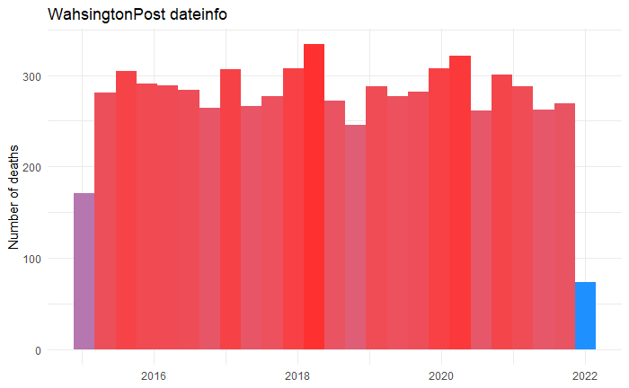

```r
WahsingtonPost$date <- ymd(WahsingtonPost$date)
ggplot(data = WahsingtonPost, aes(x = date)) +
    ggtitle("WahsingtonPost dateinfo")+
  geom_histogram(aes(fill = ..count..), bins = 25) +
  theme_minimal() +
  theme(legend.position = "none") +
  scale_fill_gradient(low = "dodgerblue", high = "firebrick1") +
  labs(x = NULL, y = "Number of deaths")
```

```r
NA
NA
```

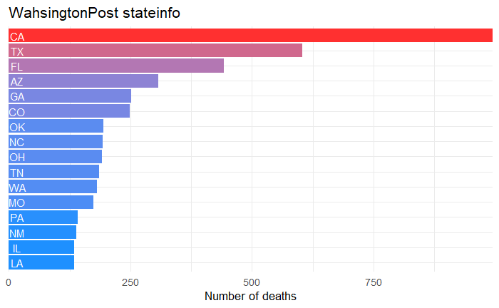

```r
stateinfo <- WahsingtonPost %>% group_by(state) %>% summarise(n = n()) %>%
  arrange(desc(n)) %>% top_n(15) %>%
  mutate(state = factor(state, levels = rev(unique(state))))
ggplot(stateinfo, aes(x = n, y = state)) +
  ggtitle("WahsingtonPost stateinfo")+
  geom_barh(stat="identity", aes(fill = n)) +
  geom_text(aes(x = 17, y = state, label=as.character(state)), color="white", size=4) +
  labs(y = NULL, x = "Number of deaths") +
  scale_fill_gradient(low = "dodgerblue", high = "firebrick1") +
  theme_minimal(base_size = 13) +
  theme(axis.text.y=element_blank()) +
  theme(legend.position = "none") +
  scale_x_continuous(expand=c(0,0))
```

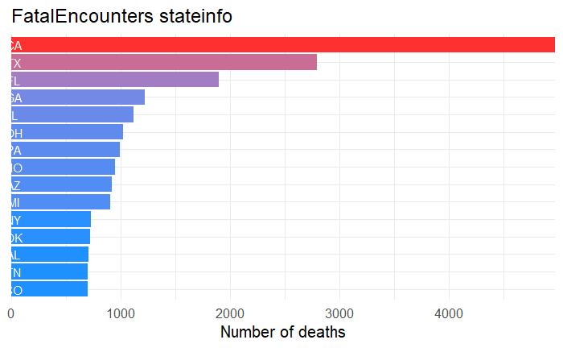

```r
stateinfo <- fatalEncounters %>% group_by(State) %>% summarise(n = n()) %>%
  arrange(desc(n)) %>% top_n(15) %>%
  mutate(State = factor(State, levels = rev(unique(State))))
ggplot(stateinfo, aes(x = n, y = State)) +
  ggtitle("FatalEncounters stateinfo")+
  geom_barh(stat="identity", aes(fill = n)) +
  geom_text(aes(x = 20, y = State, label=as.character(State)), color="white", size=4) +
  labs(y = NULL, x = "Number of deaths") +
  scale_fill_gradient(low = "dodgerblue", high = "firebrick1") +
  theme_minimal(base_size = 15) +
  theme(axis.text.y=element_blank()) +
  theme(legend.position = "none") +
  scale_x_continuous(expand=c(0,0))
```

```r
NA
NA
```

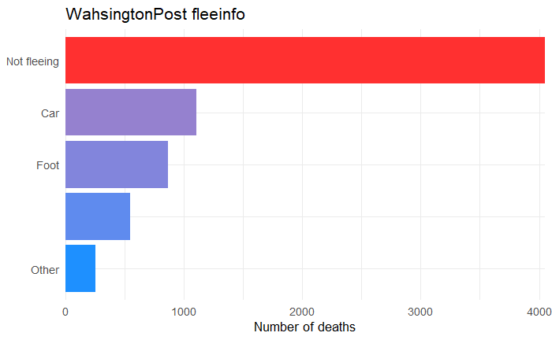

```r
fleeinfo <- WahsingtonPost %>% group_by(flee) %>% summarise(n = n()) %>%
  arrange(desc(n)) %>%
  mutate(flee = factor(flee, levels = rev(unique(flee))))

ggplot(data = fleeinfo, aes(x = n, y = flee)) +
  geom_barh(stat="identity", aes(fill = n)) +
  ggtitle("WahsingtonPost fleeinfo")+
  theme_minimal(base_size = 13) +
  theme(legend.position = "none") +
  scale_x_continuous(expand=c(0,0)) +
  scale_fill_gradient(low = "dodgerblue", high = "firebrick1") +
  labs(y = NULL, x = "Number of deaths")
```

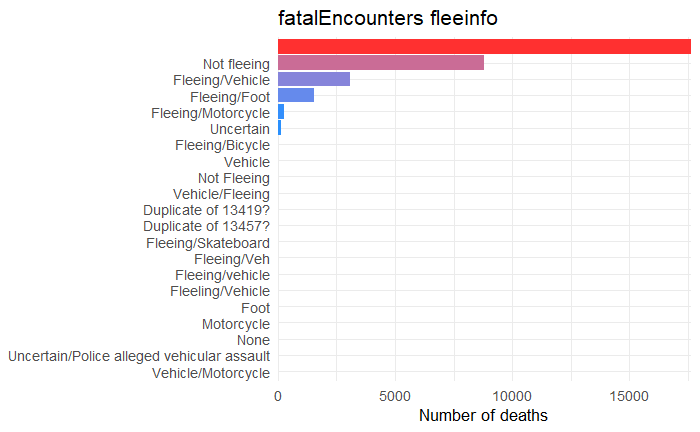

```r
fleeinfo <- fatalEncounters %>% group_by(Fleeing.Not.fleeing) %>% summarise(n = n()) %>%
  arrange(desc(n)) %>%
  mutate(Fleeing.Not.fleeing = factor(Fleeing.Not.fleeing, levels = rev(unique(Fleeing.Not.fleeing))))

ggplot(data = fleeinfo, aes(x = n, y = Fleeing.Not.fleeing)) +
  geom_barh(stat="identity", aes(fill = n)) +
  ggtitle("fatalEncounters fleeinfo")+
  theme_minimal(base_size = 13) +
  theme(legend.position = "none") +
  scale_x_continuous(expand=c(0,0)) +
  scale_fill_gradient(low = "dodgerblue", high = "firebrick1") +
  labs(y = NULL, x = "Number of deaths")
```

```r
NA
NA
```

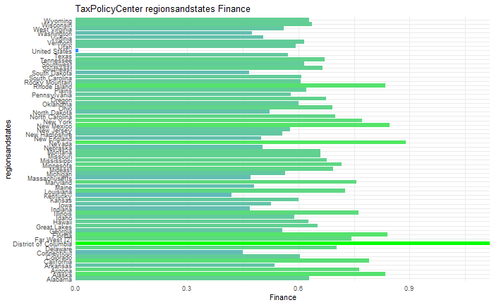

```r
ggplot(data = TaxPolicyCenter, aes(x = police ,y = regionsandstates)) +
  geom_barh(stat="identity", aes(fill = police)) +
  ggtitle("TaxPolicyCenter regionsandstates Finance")+
  theme_minimal(base_size = 8) +
  theme(legend.position = "none") +
  scale_x_continuous(expand=c(0,0)) +
  scale_fill_gradient(low = "dodgerblue", high = "green") +
  labs(y = "regionsandstates", x = "Finance")
```

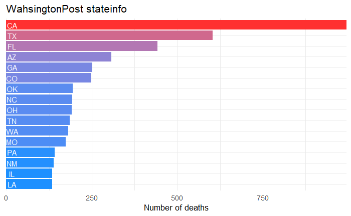

```r
stateinfo <- WahsingtonPost %>% group_by(state) %>% summarise(n = n()) %>%
  arrange(desc(n)) %>% top_n(15) %>%
  mutate(state = factor(state, levels = rev(unique(state))))
ggplot(stateinfo, aes(x = n, y = state)) +
  ggtitle("WahsingtonPost stateinfo")+
  geom_barh(stat="identity", aes(fill = n)) +
  geom_text(aes(x = 17, y = state, label=as.character(state)), color="white", size=4) +
  labs(y = NULL, x = "Number of deaths") +
  scale_fill_gradient(low = "dodgerblue", high = "firebrick1") +
  theme_minimal(base_size = 13) +
  theme(axis.text.y=element_blank()) +
  theme(legend.position = "none") +
  scale_x_continuous(expand=c(0,0))
```

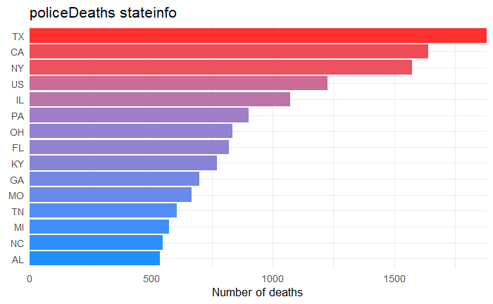

```r
stateinfo <- policeDeaths %>% group_by(state) %>% summarise(n = n()) %>%
  arrange(desc(n)) %>% top_n(15) %>%
  mutate(state = factor(state, levels = rev(unique(state))))
ggplot(data = stateinfo, aes(x = n,y = state)) +
  ggtitle("policeDeaths stateinfo")+
  geom_barh(stat="identity", aes(fill = n)) +
  theme_minimal(base_size = 13) +
  theme(legend.position = "none") +
  scale_x_continuous(expand=c(0,0)) +
  scale_fill_gradient(low = "dodgerblue", high = "firebrick1") +
  labs(y = NULL, x = "Number of deaths")
```

```r
print("TaxPolicyCenter mean")
```

```
[1] "TaxPolicyCenter mean"
```

```r
result.mean <-  mean(TaxPolicyCenter$police,na.rm = TRUE)
print(result.mean)
```

```
[1] 0.62877
```

```r
# poids des souris
# test de student pour échantillon unique
res<-t.test(TaxPolicyCenter$police, mu=TaxPolicyCenter$police[TaxPolicyCenter$regionsandstates == "California"])
print("t test for California")
```

```
[1] "t test for California"
```

```r
print(res)
```

```
    One Sample t-test

data:  TaxPolicyCenter$police
t = -8.302, df = 59, p-value = 1.691e-11
alternative hypothesis: true mean is not equal to 0.7899998
95 percent confidence interval:
 0.5899094 0.6676306
sample estimates:
mean of x
  0.62877
```

```r
print("TaxPolicyCenter median")
```

```
[1] "TaxPolicyCenter median"
```

```r
result.median <-  median(TaxPolicyCenter$police,na.rm = TRUE)
print(result.median)
```

```
[1] 0.6189762
```

```r
estimate_mode <- function(x) {
  d <- density(x,na.rm = TRUE)
  d$x[which.max(d$y)]
}

print("TaxPolicyCenter Mode")
```

```
[1] "TaxPolicyCenter Mode"
```

```r
result.mode <-  estimate_mode(TaxPolicyCenter$police)
print(result.mode)
```

```
[1] 0.6136166
```

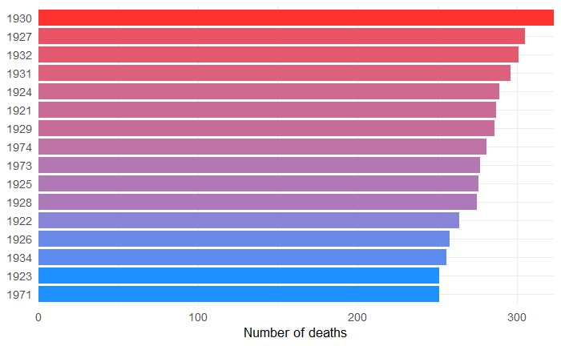

```r
yearinfo <- policeDeaths %>% group_by(year) %>% summarise(n = n()) %>%
  arrange(desc(n)) %>%  top_n(15) %>%
  mutate(year = factor(year, levels = rev(unique(year))))
ggplot(data = yearinfo, aes(x = n,y = year)) +
  geom_barh(stat="identity", aes(fill = n)) +
  theme_minimal(base_size = 13) +
  theme(legend.position = "none") +
  scale_x_continuous(expand=c(0,0)) +
  scale_fill_gradient(low = "dodgerblue", high = "firebrick1") +
  labs(y = NULL, x = "Number of deaths")
```

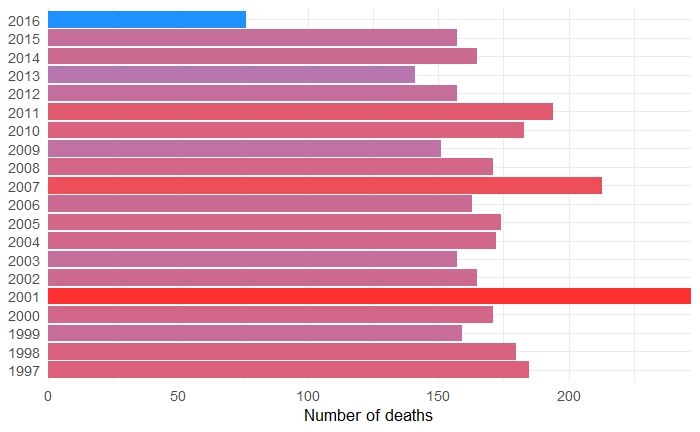

```r
yearinfo <- policeDeaths %>% group_by(year) %>% summarise(n = n()) %>%
  arrange(desc(year)) %>%
  mutate(year = factor(year, levels = rev(unique(year))))

ggplot(data = yearinfo[0:20,], aes(x = n,y = year)) +
  geom_barh(stat="identity", aes(fill = n)) +
  theme_minimal(base_size = 13) +
  theme(legend.position = "none") +
  scale_x_continuous(expand=c(0,0)) +
  scale_fill_gradient(low = "dodgerblue", high = "firebrick1") +
  labs(y = NULL, x = "Number of deaths")
```

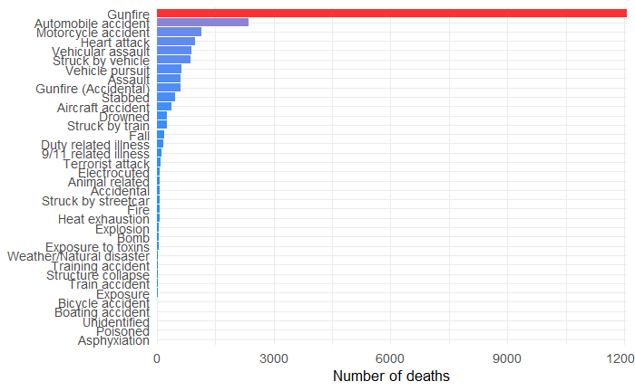

```r
causeinfo <- policeDeaths %>% group_by(cause_short) %>% summarise(n = n()) %>%
  arrange(desc(n)) %>%
  mutate(cause_short = factor(cause_short, levels = rev(unique(cause_short))))

ggplot(data = causeinfo, aes(x = n,y = cause_short)) +
  geom_barh(stat="identity", aes(fill = n)) +
  theme_minimal(base_size = 13) +
  theme(legend.position = "none") +
  scale_x_continuous(expand=c(0,0)) +
  scale_fill_gradient(low = "dodgerblue", high = "firebrick1") +
  labs(y = NULL, x = "Number of deaths")
```

```r
NA
NA
```